# Prak MPDW pertemuan 6 dan 7

Aquila Putra N.

2026-09-30

# Setting Up

## Packages

```r
library(ggplot2)
library(tsibble)
library(tseries)
library(MASS)
library(forecast)
library(TSA)
library(TTR)
library(aTSA)
library(graphics)
library(readxl)
library(dplyr)
library(lmtest)
library(stringr)
library(readr)
```

## Data Input

```r
data_USD <- read_csv("C:\\Users\\Aquila\\Downloads\\usd_idr_daily_cleaned.csv")
datakurs <- data_USD %>%
  filter(str_starts(Date, "2024"))%>%
  select(Date, Close)
```

```r
datakurs
```

| Date | Close |
| --- | --- |
| 2024-01-01 00:00:00 | 15383.1 |
| 2024-01-02 00:00:00 | 15383.0 |
| 2024-01-03 00:00:00 | 15498.0 |
| 2024-01-04 00:00:00 | 15555.0 |
| 2024-01-05 00:00:00 | 15511.0 |
| 2024-01-08 00:00:00 | 15477.5 |
| 2024-01-09 00:00:00 | 15495.5 |
| 2024-01-10 00:00:00 | 15534.5 |
| 2024-01-11 00:00:00 | 15555.0 |
| 2024-01-12 00:00:00 | 15556.5 |

[output cut: 252 more lines]

```r
data.ts <-ts(datakurs$Close)
summary(data.ts)
```

```
##    Min. 1st Qu.  Median    Mean 3rd Qu.    Max.
##   15069   15615   15827   15846   16116   16492
```

# Eksplorasi Data

## Plot Data Penuh

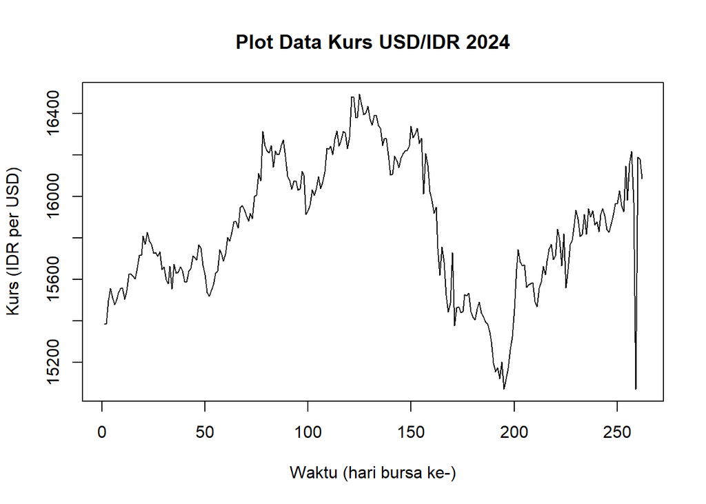

```r
plot.ts(data.ts, lty = 1, xlab = "Waktu (hari bursa ke-)",
        ylab = "Kurs (IDR per USD)", main = "Plot Data Kurs USD/IDR 2024")
```

Berdasarkan plot data deret waktu, terlihat bahwa data cenderung mengalami fluktuasi dengan beberapa pola kenaikan dan penurunan pada periode pengamatan. Berdasarkan pola data, pembagian data latih dan data uji ditetapkan dengan proporsi 80:20, dengan 209 observasi sebagai data latih dan 53 observasi sebagai data uji.

## Plot Data Latih dan Uji

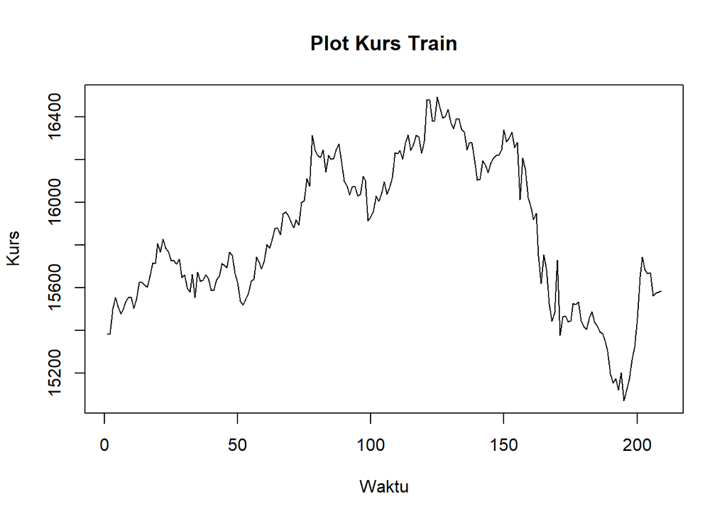

```r
n       <- length(data.ts)
n_test  <- 53
n_train <- n - n_test

kurstrain <- datakurs$Close[1:n_train]
train.ts  <- ts(kurstrain)
plot.ts(train.ts, lty=1, xlab="Waktu", ylab="Kurs", main="Plot Kurs Train")
```

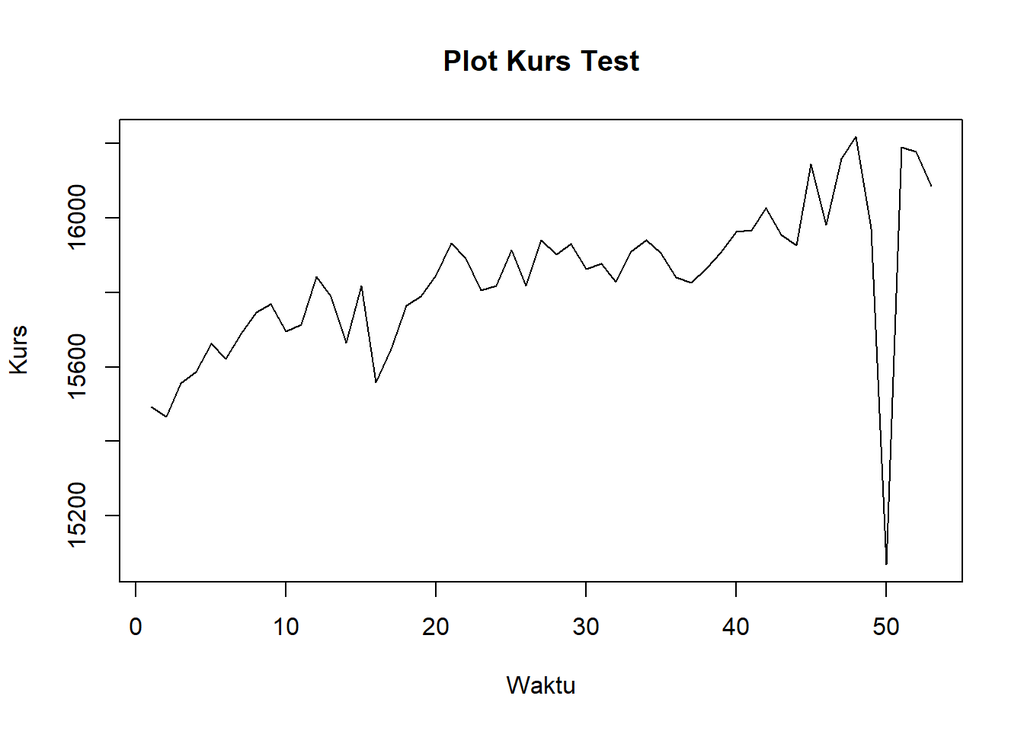

```r
kurstest <- datakurs$Close[(n_train+1):n]
test.ts  <- ts(kurstest)
plot.ts(test.ts, lty=1, xlab="Waktu", ylab="Kurs", main="Plot Kurs Test")
```

Berdasarkan plot data deret waktu pada data latih, data menunjukkan perubahan fluktuasi di sekitar nilai tengah yang tidak konstan sehingga terdapat indikasi ketidakstasioneran. Indikasi tersebut kemudian dikonfirmasi menggunakan uji ADF.

# Uji Stasioneritas Data

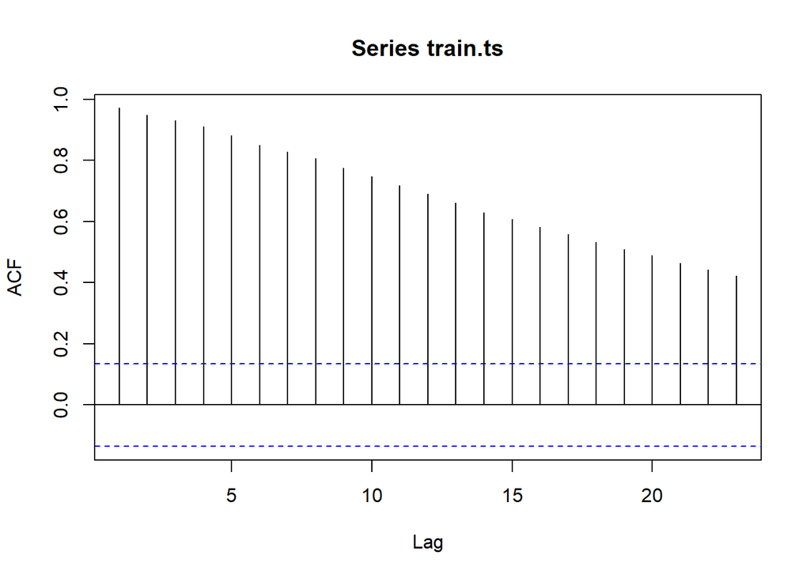

```r
acf(train.ts)
```

```r
tseries::adf.test(train.ts)
```

```
##
##  Augmented Dickey-Fuller Test
##
## data:  train.ts
## Dickey-Fuller = -1.9006, Lag order = 5, p-value = 0.6177
## alternative hypothesis: stationary
```

$H_0$: data tidak stasioner dalam rataan. Plot ACF bersifat tails off dan uji ADF menghasilkan *p-value* = 0.6177 > 0.05, sehingga gagal tolak $H_0$ yang artinya dapat dikatakan bahwa data bersifat tidak stasioner dalam rataan. Ketidakstasioneran perlu ditangani.

## Uji ADF

```r
tseries::adf.test(train.ts)
```

```
##
##  Augmented Dickey-Fuller Test
##
## data:  train.ts
## Dickey-Fuller = -1.9006, Lag order = 5, p-value = 0.6177
## alternative hypothesis: stationary
```

$H_0$ : Data tidak stasioner dalam rataan $H_1$ : Data stasioner dalam rataan

Berdasarkan uji ADF tersebut, didapat *p-value* sebesar 0.6177 yang lebih besar dari taraf nyata 5% sehingga gagal tolak $H_0$ dan menandakan bahwa data tidak stasioner dalam rataan. Hal ini sesuai dengan hasil eksplorasi menggunakan plot time series dan plot ACF, sehingga ketidakstasioneran model kedepannya harus ditangani.

## Plot Box-Cox

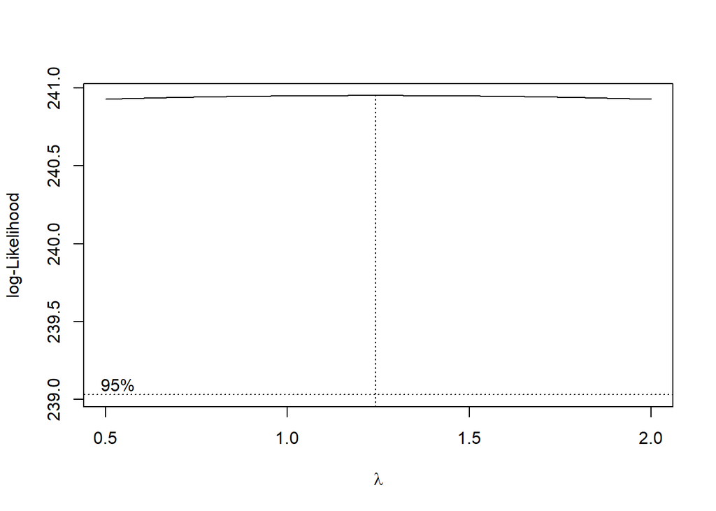

```r
index <- seq(1:n_train)
bc <- boxcox(train.ts ~ index, lambda = seq(0.5, 2, by = 0.1))
```

```r
lambda_opt <- bc$x[which.max(bc$y)]
lambda_opt
```

```
## [1] 1.242424
```

```r
ci_lambda <- bc$x[bc$y > max(bc$y) - 0.5 * qchisq(0.95, df = 1)]
ci_lower <- min(ci_lambda)
ci_upper <- max(ci_lambda)
c(Batas_Bawah = ci_lower, Batas_Atas = ci_upper)
```

```
## Batas_Bawah  Batas_Atas
##         0.5         2.0
```

# Penanganan Ketidakstasioneran Data

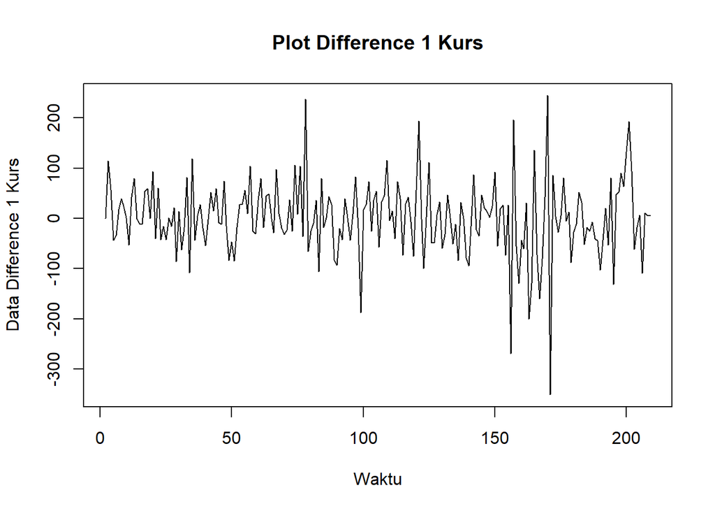

```r
train.diff <- diff(train.ts, differences = 1)
plot.ts(train.diff, lty=1, xlab="Waktu", ylab="Data Difference 1 Kurs",
        main="Plot Difference 1 Kurs")
```

```r
acf(train.diff)
```

[output not shown]

```r
tseries::adf.test(train.diff)
```

```
##
##  Augmented Dickey-Fuller Test
##
## data:  train.diff
## Dickey-Fuller = -5.4963, Lag order = 5, p-value = 0.01
## alternative hypothesis: stationary
```

Berdasarkan plot data deret waktu pada difference 1, terlihat bahwa data bergerak dan berfluktuasi di sekitar nilai tengah yang relatif konstan, yaitu di sekitar nol, serta tidak menunjukkan adanya tren maupun pola musiman yang jelas. Hal ini mengindikasikan bahwa data sudah stasioner dalam rataan setelah dilakukan differencing orde pertama.

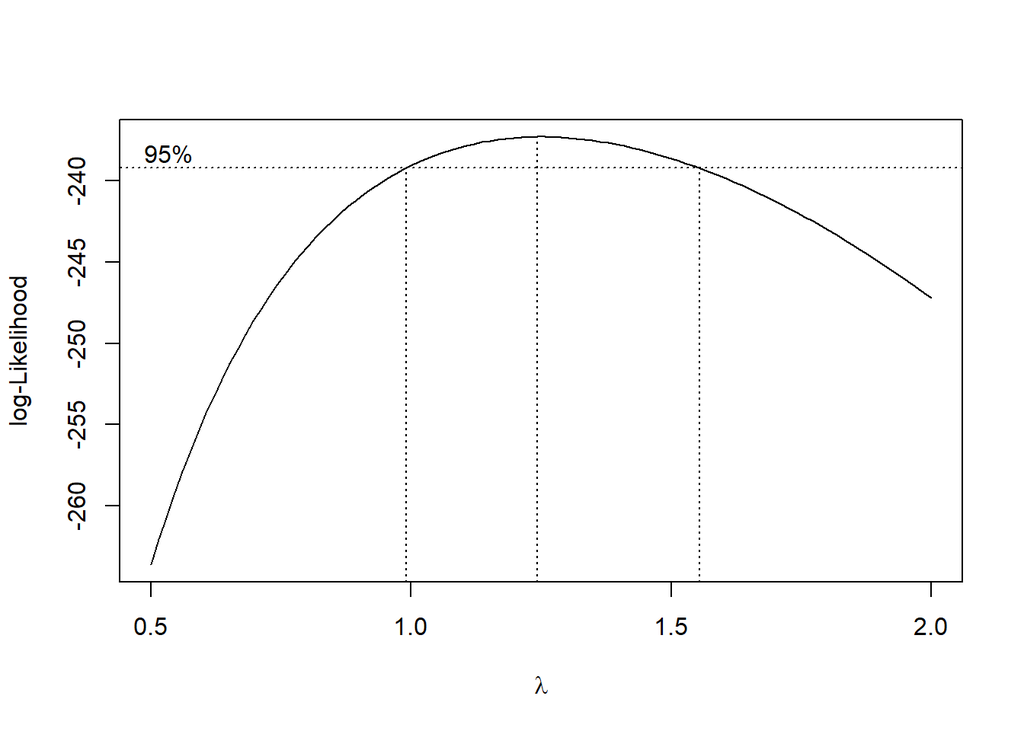

```r
index_diff <- seq(1:length(train.diff))
min_val <- min(train.diff)
if (min_val <= 0) {
  konstanta <- abs(min_val) + 1
  train.diff_shifted <- train.diff + konstanta
} else {
  train.diff_shifted <- train.diff
}
bc_diff <- boxcox(train.diff_shifted ~ index_diff, lambda = seq(0.5, 2, by = 0.1))
```

```r
lambda_opt_diff <- bc_diff$x[which.max(bc_diff$y)]
lambda_opt_diff
```

```
## [1] 1.242424
```

```r
ci_lambda_diff <- bc_diff$x[bc_diff$y > max(bc_diff$y) - 0.5 * qchisq(0.95, df = 1)]
c(Batas_Bawah = min(ci_lambda_diff), Batas_Atas = max(ci_lambda_diff))
```

```
## Batas_Bawah  Batas_Atas
##    1.000000    1.545455
```

## Plot ACF

```r
acf(train.diff)
```

[output not shown]

## Uji ADF

```r
tseries::adf.test(train.diff)
```

```
##
##  Augmented Dickey-Fuller Test
##
## data:  train.diff
## Dickey-Fuller = -5.4963, Lag order = 5, p-value = 0.01
## alternative hypothesis: stationary
```

$H_0$ : Data tidak stasioner dalam rataan $H_1$ : Data stasioner dalam rataan

Berdasarkan uji ADF tersebut, didapat p-value sebesar 0.01 yang lebih kecil dari taraf nyata 5% sehingga tolak H0 atau data stasioner dalam rataan. Hal ini sesuai dengan hasil eksplorasi menggunakan plot time series dan plot ADF, sehingga dalam hal ini ketidakstasioneran data sudah berhasil ditangani dan data dapat dilanjutkan ke tahap pemodelan ARIMA.

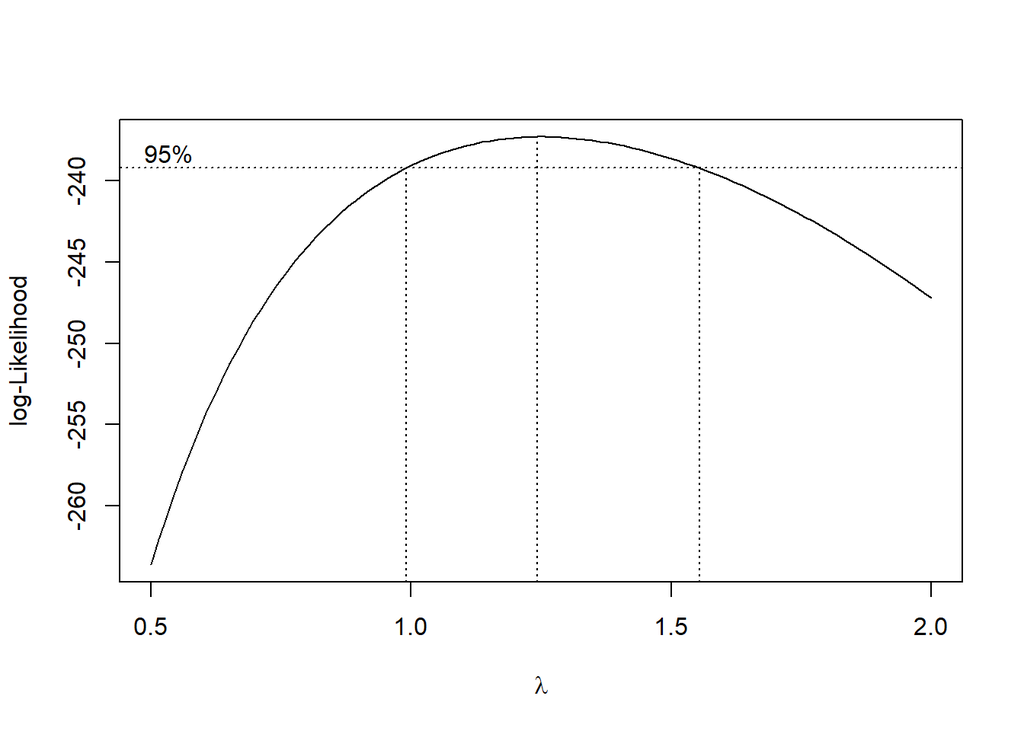

```r
library(MASS)

# 1. Sesuaikan panjang index karena differencing menghilangkan 1 observasi awal
index_diff <- seq(1:length(train.diff))

# 2. Cek apakah ada nilai negatif/nol. Jika ada, tambahkan konstanta (c)
# agar nilai minimum data menjadi > 0 (misalnya menjadi 1)
min_val <- min(train.diff)

if (min_val <= 0) {
  c <- abs(min_val) + 1
  train.diff_shifted <- train.diff + c
} else {
  train.diff_shifted <- train.diff
}

# 3. Plot Box-Cox pada data yang sudah di-shift
bc_diff <- boxcox(train.diff_shifted ~ index_diff, lambda = seq(0.5, 2, by = 0.1))
```

```r
# 4. Nilai lambda optimum (rounded)
lambda_opt_diff <- bc_diff$x[which.max(bc_diff$y)]
print(paste("Lambda optimum setelah diff:", lambda_opt_diff))
```

```
## [1] "Lambda optimum setelah diff: 1.24242424242424"
```

```r
# 5. Selang kepercayaan 95% untuk lambda
ci_lambda_diff <- bc_diff$x[bc_diff$y > max(bc_diff$y) - 0.5 * qchisq(0.95, df = 1)]

# Batas bawah dan batas atas
ci_lower_diff <- min(ci_lambda_diff)
ci_upper_diff <- max(ci_lambda_diff)

c(Batas_Bawah = ci_lower_diff, Batas_Atas = ci_upper_diff)
```

```
## Batas_Bawah  Batas_Atas
##    1.000000    1.545455
```

# Identifikasi Model

```r
acf(train.diff)
```

[output not shown]

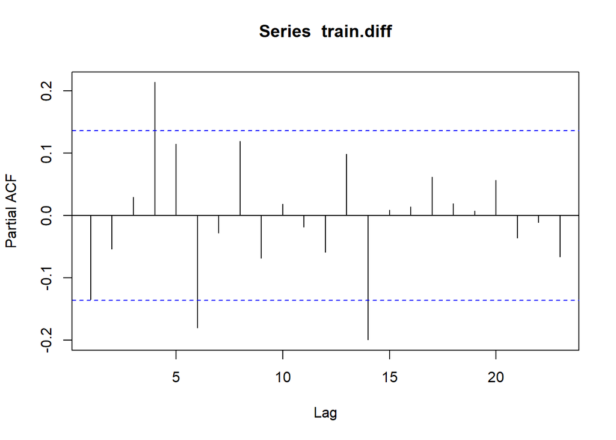

```r
pacf(train.diff)
```

```r
eacf(train.diff)
```

```
## AR/MA
##   0 1 2 3 4 5 6 7 8 9 10 11 12 13
## 0 o o o x o x o x o o o  o  o  x
## 1 x o o x o x o x o o o  o  o  x
## 2 x o o o o o o o o o o  o  o  x
## 3 o x x o o o o o o o o  o  o  x
## 4 x x x x o o o o o o o  o  o  x
## 5 x x o x o o o o o o o  o  o  x
## 6 x x x o o o o o o o o  o  o  x
## 7 x x o o o o o o o o o  o  o  o
```

# Pendugaan Parameter Model Tentatif

```r
# Model 1: ARIMA(0,1,1) -> ARIMA(0,0,1) pada train.diff
model1.da <- Arima(train.diff, order = c(0, 0, 1), method = "ML", include.mean = FALSE)
summary(model1.da); lmtest::coeftest(model1.da)
```

```
## Series: train.diff
## ARIMA(0,0,1) with zero mean
##
## Coefficients:
##           ma1
##       -0.1416
## s.e.   0.0681
##
## sigma^2 = 5418:  log likelihood = -1188.79
## AIC=2381.59   AICc=2381.64   BIC=2388.26
##
## Training set error measures:
##                   ME     RMSE      MAE MPE MAPE      MASE        ACF1
## Training set 1.11974 73.43225 52.68808 Inf  Inf 0.6565077 0.000745913
```

```
##
## z test of coefficients:
##
##      Estimate Std. Error z value Pr(>|z|)
## ma1 -0.141605   0.068057 -2.0807  0.03746 *
## ---
## Signif. codes:  0 '***' 0.001 '**' 0.01 '*' 0.05 '.' 0.1 ' ' 1
```

```r
# Model 2: ARIMA(0,1,2) -> ARIMA(0,0,2) pada train.diff
model2.da <- Arima(train.diff, order = c(0, 0, 2), method = "ML", include.mean = FALSE)
summary(model2.da); lmtest::coeftest(model2.da)
```

```
## Series: train.diff
## ARIMA(0,0,2) with zero mean
##
## Coefficients:
##           ma1      ma2
##       -0.1383  -0.0088
## s.e.   0.0710   0.0608
##
## sigma^2 = 5444:  log likelihood = -1188.78
## AIC=2383.56   AICc=2383.68   BIC=2393.58
##
## Training set error measures:
##                    ME     RMSE      MAE MPE MAPE      MASE         ACF1
## Training set 1.126492 73.42864 52.64603 Inf  Inf 0.6559837 -0.001711046
```

```
##
## z test of coefficients:
##
##      Estimate Std. Error z value Pr(>|z|)
## ma1 -0.138273   0.070969 -1.9484  0.05137 .
## ma2 -0.008785   0.060797 -0.1445  0.88511
## ---
## Signif. codes:  0 '***' 0.001 '**' 0.01 '*' 0.05 '.' 0.1 ' ' 1
```

```r
# Model 3: ARIMA(2,1,1) -> ARIMA(2,0,1) pada train.diff (Kandidat Utama EACF)
model3.da <- Arima(train.diff, order = c(2, 0, 1), method = "ML", include.mean = FALSE)
summary(model3.da); lmtest::coeftest(model3.da)
```

```
## Series: train.diff
## ARIMA(2,0,1) with zero mean
##
## Coefficients:
##           ar1      ar2     ma1
##       -0.2042  -0.0631  0.0635
## s.e.   0.4537   0.0904  0.4499
##
## sigma^2 = 5462:  log likelihood = -1188.62
## AIC=2385.24   AICc=2385.44   BIC=2398.59
##
## Training set error measures:
##                    ME     RMSE      MAE MPE MAPE      MASE          ACF1
## Training set 1.143718 73.37112 52.59454 Inf  Inf 0.6553421 -0.0002510991
```

```
##
## z test of coefficients:
##
##      Estimate Std. Error z value Pr(>|z|)
## ar1 -0.204214   0.453696 -0.4501   0.6526
## ar2 -0.063121   0.090422 -0.6981   0.4851
## ma1  0.063499   0.449931  0.1411   0.8878
```

```r
# Model 4: ARIMA(3,1,3) -> ARIMA(3,0,3) pada train.diff (Kandidat Alternatif EACF)
model4.da <- Arima(train.diff, order = c(3, 0, 3), method = "ML", include.mean = FALSE)
summary(model4.da); lmtest::coeftest(model4.da)
```

```
## Series: train.diff
## ARIMA(3,0,3) with zero mean
##
## Coefficients:
```

```
##          ar1     ar2      ar3      ma1     ma2     ma3
##       0.1565  0.0801  -0.4941  -0.3308  -0.034  0.6335
## s.e.     NaN     NaN      NaN      NaN     NaN     NaN
##
## sigma^2 = 5301:  log likelihood = -1184.13
## AIC=2382.27   AICc=2382.83   BIC=2405.63
##
## Training set error measures:
##                   ME     RMSE      MAE  MPE MAPE      MASE        ACF1
## Training set 1.09223 71.75161 53.59489 -Inf  Inf 0.6678068 0.008686078
```

```
##
## z test of coefficients:
##
##      Estimate Std. Error z value Pr(>|z|)
## ar1  0.156519        NaN     NaN      NaN
## ar2  0.080097        NaN     NaN      NaN
## ar3 -0.494147        NaN     NaN      NaN
## ma1 -0.330781        NaN     NaN      NaN
## ma2 -0.034035        NaN     NaN      NaN
## ma3  0.633459        NaN     NaN      NaN
```

## Ringkasan AIC

```r
model_tentatif <- data.frame(
  Model = c("ARIMA(0,1,1)","ARIMA(0,1,2)","ARIMA(2,1,1)","ARIMA(3,1,3)"),
  AIC = c(AIC(model1.da),AIC(model2.da),AIC(model3.da),AIC(model4.da)),
  BIC = c(BIC(model1.da),BIC(model2.da),BIC(model3.da),BIC(model4.da))
)
model_tentatif
```

| Model | AIC | BIC |
| --- | --- | --- |
| ARIMA(0,1,1) | 2381.586 | 2388.261 |
| ARIMA(0,1,2) | 2383.565 | 2393.577 |
| ARIMA(2,1,1) | 2385.243 | 2398.593 |
| ARIMA(3,1,3) | 2382.265 | 2405.628 |

$$\textbf{ARIMA(0,1,1)}\
(\text{AIC}=2381{,}586,\ \text{BIC}=2388{,}261)$$

# Analisis Sisaan

Model terbaik hasil identifikasi kemudian dicek asumsi sisaannya. Sisaan model ARIMA harus memenuhi asumsi normalitas, kebebasan sisaan, dan kehomogenan ragam. Diagnostik model dilakukan secara eksplorasi dan uji formal.

## Eksplorasi Sisaan Model ARIMA(0,1,1)

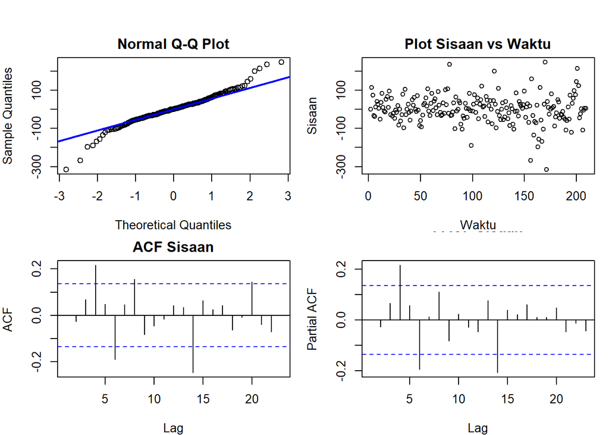

```r
sisaan.da <- model1.da$residuals

par(mfrow = c(2,2), mar = c(4,4,2,1), oma = c(0,0,2,0))
qqnorm(sisaan.da, main = "Normal Q-Q Plot")
qqline(sisaan.da, col = "blue", lwd = 2)
plot(sisaan.da, type = "p", main = "Plot Sisaan vs Waktu",
     xlab = "Waktu", ylab = "Sisaan")
acf(sisaan.da, main = "ACF Sisaan")
pacf(sisaan.da, main = "PACF Sisaan")
```

Secara eksploratif, Normal Q-Q Plot menunjukkan bahwa sebagian besar sisaan mengikuti garis diagonal, meskipun terdapat penyimpangan pada bagian ekor. Plot sisaan terhadap waktu menunjukkan bahwa sisaan menyebar di sekitar nol tanpa pola sistematis yang jelas. Sementara itu, ACF dan PACF sisaan menunjukkan bahwa sebagian besar spike berada dalam batas interval kepercayaan, meskipun terdapat beberapa spike yang melewati batas. Oleh karena itu, kenormalan dan independensi sisaan perlu dikonfirmasi lebih lanjut menggunakan pengujian formal.